# COVID-19 data Analysis

[figure not shown]

South Korea COVID-19 data Analysis

1. Project Introduction
2. Preparation and Initial Inspection
   1. Observations before cleaning
3. Data Cleaning
4. Exploratory Analysis
   1. Glance to Case dataset
   2. Geospatial Analysis
   3. Church visiting
   4. Time Series Analysis
   5. Relationship between patiens age, covid confirmed case and decease
   6. Seoul floating population EDA
5. Summary and Suggestions

#### [Notebook by Mažvydas Brikas](https://www.linkedin.com/in/mazvydas-brikas/) [Turing College](https://www.turingcollege.com/)

# 1. Project Introduction

The main objective of this project is to analyze South Korea's COVID-19 crisis using the provided dataset. </p>  
COVID-19 crisis:

The world is still struggling with one of the most rapidly spreading pandemics. There are a lot of people who say that data is the best weapon we can use in this "Corona Fight."

Imagine that you are one of the best data scientists in your country. The president of your country asked you to analyze the COVID-19 patient-level data of South Korea and prepare your homeland for the next wave of the pandemic. You, as the lead data scientist of your country have to create and prove a plan of fighting the pandemics in your country by analyzing the provided data. You must get the most critical insights using learned data science techniques and present them to the lead of your country. </p>  
Objectives:

- Practice identifying opportunities for data analysis.
- Practice performing EDA.
- Practice working with data from Kaggle.
- Practice visualizing data with Matplotlib & Seaborn.
- Practice reading data, performing queries, and filtering data using Pandas.

You can download dataset from [Kaggle](https://www.kaggle.com/datasets/kimjihoo/coronavirusdataset).

You can download daily covid cases and deaths by date reported to WHO - [WHO Coronavirus (COVID-19) Dashboard](https://covid19.who.int/data).

You can download World Population data from [United Nations](https://population.un.org/wpp/Download/Standard/Population/).

# 2. Preparation and Initial Inspection

```python
import pandas as pd
import matplotlib.pyplot as plt
import numpy as np
import seaborn as sns
import folium
from statsmodels.tsa.arima.model import ARIMA
from sklearn.cluster import KMeans
from sklearn.preprocessing import StandardScaler


# Load the CSV and xlsx files
case = pd.read_csv('Case.csv')
patient_info = pd.read_csv('PatientInfo.csv')
policy = pd.read_csv('Policy.csv')
region = pd.read_csv('Region.csv')
search_trend = pd.read_csv('SearchTrend.csv')
seoul_floating = pd.read_csv('SeoulFloating.csv')
time = pd.read_csv('Time.csv')
time_age = pd.read_csv('TimeAge.csv')
time_gender = pd.read_csv('TimeGender.csv')
time_province = pd.read_csv('TimeProvince.csv')
weather = pd.read_csv('Weather.csv')
who_data = pd.read_csv('WHO-COVID-19-global-data.csv')
population = pd.read_excel('Total Korea population.xlsx')

# Set the default color palette for Seaborn
sns.set_palette('bright')
```

## 2.1 Observations before cleaning

```python
# Inspect the data
case.info()
```

[output not shown]

```python
policy.info()
policy.head()
```

```
<class 'pandas.core.frame.DataFrame'>
RangeIndex: 61 entries, 0 to 60
Data columns (total 7 columns):
 #   Column      Non-Null Count  Dtype
---  ------      --------------  -----
 0   policy_id   61 non-null     int64
 1   country     61 non-null     object
 2   type        61 non-null     object
 3   gov_policy  61 non-null     object
 4   detail      59 non-null     object
 5   start_date  61 non-null     object
 6   end_date    24 non-null     object
dtypes: int64(1), object(6)
memory usage: 3.5+ KB
```

|  | policy_id | country | type | gov_policy | detail | start_date | end_date |
| --- | --- | --- | --- | --- | --- | --- | --- |
| 0 | 1 | Korea | Alert | Infectious Disease Alert Level | Level 1 (Blue) | 2020-01-03 | 2020-01-19 |
| 1 | 2 | Korea | Alert | Infectious Disease Alert Level | Level 2 (Yellow) | 2020-01-20 | 2020-01-27 |
| 2 | 3 | Korea | Alert | Infectious Disease Alert Level | Level 3 (Orange) | 2020-01-28 | 2020-02-22 |
| 3 | 4 | Korea | Alert | Infectious Disease Alert Level | Level 4 (Red) | 2020-02-23 | NaN |
| 4 | 5 | Korea | Immigration | Special Immigration Procedure | from China | 2020-02-04 | NaN |

```python
time_age.info()
```

[output not shown]

```python
seoul_floating.info()
```

```
<class 'pandas.core.frame.DataFrame'>
RangeIndex: 1084800 entries, 0 to 1084799
Data columns (total 7 columns):
 #   Column      Non-Null Count    Dtype
---  ------      --------------    -----
 0   date        1084800 non-null  object
 1   hour        1084800 non-null  int64
 2   birth_year  1084800 non-null  int64
 3   sex         1084800 non-null  object
 4   province    1084800 non-null  object
 5   city        1084800 non-null  object
 6   fp_num      1084800 non-null  int64
dtypes: int64(3), object(4)
memory usage: 57.9+ MB
```

```python
who_data.info()
```

```
<class 'pandas.core.frame.DataFrame'>
RangeIndex: 329904 entries, 0 to 329903
Data columns (total 8 columns):
 #   Column             Non-Null Count   Dtype
---  ------             --------------   -----
 0   Date_reported      329904 non-null  object
 1   Country_code       328512 non-null  object
 2   Country            329904 non-null  object
 3   WHO_region         329904 non-null  object
 4   New_cases          329904 non-null  int64
 5   Cumulative_cases   329904 non-null  int64
 6   New_deaths         329904 non-null  int64
 7   Cumulative_deaths  329904 non-null  int64
dtypes: int64(4), object(4)
memory usage: 20.1+ MB
```

# 3. Data Cleaning

Missing value, duplicates and feature corrections.

```python
case.isna().sum()
```

```
 case_id          0
province          0
city              0
group             0
infection_case    0
confirmed         0
latitude          0
longitude         0
dtype: int64
```

```python
# converting location values to numeric and handling errors
case['latitude'] = pd.to_numeric(case['latitude'], errors='coerce')
case['longitude'] = pd.to_numeric(case['longitude'], errors='coerce')

case['latitude'].fillna(0, inplace=True)
case['longitude'].fillna(0, inplace=True)
```

```python
#removing duplicated rows
Dup_Rows = case[case.duplicated()]
print("\n\nDuplicate Rows : \n {}".format(Dup_Rows))
```

```
Duplicate Rows :
 Empty DataFrame
Columns: [ case_id, province, city, group, infection_case, confirmed, latitude, longitude]
Index: []
```

```python
# checking how data looks after cleaning
case.info()
```

[output not shown]

```python
# removing 's' from the 'age' values and converting to numeric
time_age['age'] = pd.to_numeric(time_age['age'].str.replace('s', ''), errors='coerce')
```

```python
# checking how data looks after cleaning
time_age.info()
```

```
<class 'pandas.core.frame.DataFrame'>
RangeIndex: 1089 entries, 0 to 1088
Data columns (total 5 columns):
 #   Column     Non-Null Count  Dtype
---  ------     --------------  -----
 0   date       1089 non-null   object
 1   time       1089 non-null   int64
 2   age        1089 non-null   int64
 3   confirmed  1089 non-null   int64
 4   deceased   1089 non-null   int64
dtypes: int64(4), object(1)
memory usage: 42.7+ KB
```

### Data quality is pretty good.

- Handled duplicates and missing values.
- Transformed age values from time_age and converted to numeric
- Converted location values to numeric and handled errors

# 4. Exploratory Analysis

## 4.1 Glance to Case dataset

```python
# Basic statistics
case.describe()
```

|  | case_id | confirmed | latitude | longitude |
| --- | --- | --- | --- | --- |
| count | 1.740000e+02 | 174.000000 | 65.000000 | 65.000000 |
| mean | 2.686216e+06 | 65.488506 | 36.694051 | 127.584885 |
| std | 1.943218e+06 | 355.097654 | 0.911466 | 0.823087 |
| min | 1.000001e+06 | 0.000000 | 35.078825 | 126.316746 |
| 25% | 1.100006e+06 | 4.000000 | 35.848190 | 126.956405 |
| 50% | 1.700004e+06 | 10.000000 | 37.000354 | 127.113900 |
| 75% | 4.100004e+06 | 31.750000 | 37.522331 | 128.466653 |
| max | 7.000004e+06 | 4511.000000 | 37.758635 | 129.125600 |

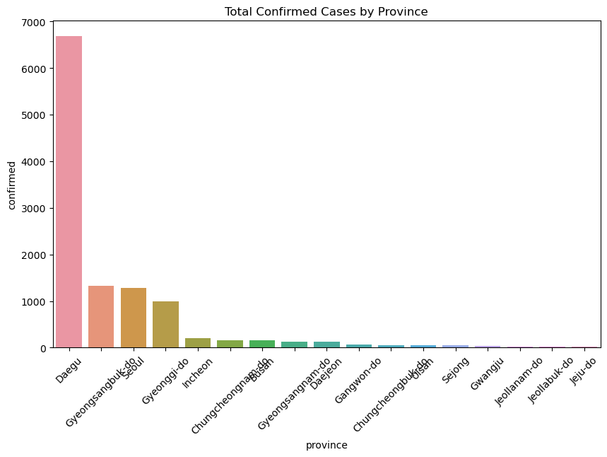

|  | province | confirmed |
| --- | --- | --- |
| 3 | Daegu | 6680 |
| 8 | Gyeongsangbuk-do | 1324 |
| 15 | Seoul | 1280 |
| 7 | Gyeonggi-do | 1000 |
| 10 | Incheon | 202 |

```python
province_confirmed = case.groupby('province')['confirmed'].sum().reset_index()

province_confirmed = province_confirmed.sort_values(by='confirmed', ascending=False)

plt.figure(figsize=(10, 6))
sns.barplot(data=province_confirmed, x='province', y='confirmed',)
plt.xticks(rotation=45)
plt.title('Total Confirmed Cases by Province')
plt.show()

table_view = province_confirmed[['province', 'confirmed']]
table_view.head()
```

We can see that Daegu is the leading province in confirmed cases.

## 4.2 Geospatial Analysis

### Let's try to understand cases of geographical spread using longitude and latitude.

```python
# Creating a map centered on a specific location
m = folium.Map(location=[37.5665, 126.9780], zoom_start=10)

# Creating a colormap for marker colors
colormap = {
    0: 'blue',
    1: 'green',
    2: 'orange',
    'default': 'red',
}

# Iterating through the case DataFrame and adding markers for each confirmed case
for index, row in case.iterrows():
    lat, lon = row['latitude'], row['longitude']
    confirmed = row['confirmed']
    description = f"Confirmed Cases: {confirmed}"

    # Determine marker color based on the number of cases or use the default color
    marker_color = colormap.get(confirmed // 100, colormap['default'])
    marker_icon = folium.Icon(icon='cloud', color=marker_color, icon_color='white')

    # Creating a marker for each case
    folium.Marker(
        location=[lat, lon],
        popup=description,
        icon=marker_icon,
    ).add_to(m)

# Setting the map language to English
folium.TileLayer('cartodbpositron', name='English').add_to(m)
folium.TileLayer('cartodbdark_matter', name='Dark Mode').add_to(m)
folium.LayerControl().add_to(m)


# Displaying the map
m.save('confirmed_cases_map.html')

m
```

Make this Notebook Trusted to load map: File -> Trust Notebook

[interactive chart not shown]

From the confirmed covid cases map, we ca see that main two hot areas are Daegu and Seoul regions. Daegu in particular stands out with one location with 4511 confirmed cases.

```python
infection_case_confirmed = case.groupby('infection_case')['confirmed'].sum().reset_index()

infection_case_confirmed = infection_case_confirmed.sort_values(by='confirmed', ascending=False)

infection_case_confirmed.head()
```

|  | infection_case | confirmed |
| --- | --- | --- |
| 62 | Shincheonji Church | 5213 |
| 76 | contact with patient | 1403 |
| 77 | etc | 1192 |
| 80 | overseas inflow | 949 |
| 34 | Itaewon Clubs | 271 |

Shincheonji Church is first by a big margin by confirmed cases.

On 19 February, the number of confirmed cases increased by 20. On 20 February 70[5] new cases were confirmed, giving a total of 104 confirmed cases, according to the KCDC. According to Reuters, KCDC attributed the sudden jump of 70 cases linked to "Patient No. 31", who had participated in a gathering in Daegu at the Shincheonji Church of Jesus the Temple of the Tabernacle of the Testimony.[5]

On 20 February, the streets of Daegu were empty in reaction to the Shincheonji outbreak. A resident described the reaction, stating "It's like someone dropped a bomb in the middle of the city. It looks like a zombie apocalypse."[5] The first death was reported[48] in a mental ward of Cheongdo Daenam Hospital in Cheongdo County. According to the mayor of Daegu, the number of suspected cases as of 21 February was 544 among 4,400 examined followers of the church.[49]

[Wikipedia article about Shincheonji Church case](https://en.wikipedia.org/wiki/COVID-19_pandemic_in_South_Korea#18_February_%E2%80%93_29_February) .

**Suggestion:**  
Regional Preparedness: Given Daegu's history as a hotspot, it's essential to ensure that the healthcare infrastructure and testing facilities in this region are well-prepared to handle a surge in cases. Regular testing and monitoring should be maintained.

## 4.3 Church visiting

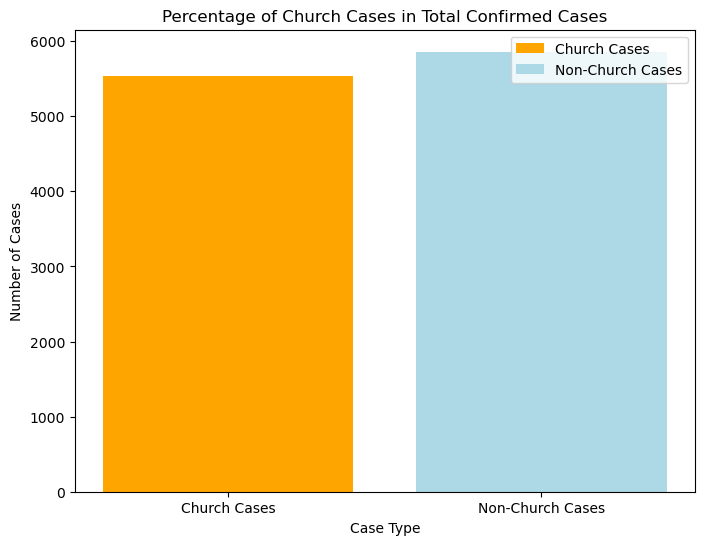

```
48.582711715664765
```

```python
total_confirmed = case['confirmed'].sum()

church_cases = case[case['infection_case'].str.contains('church', case=False, na=False)]

church_confirmed = church_cases['confirmed'].sum()

percentage_church = (church_confirmed / total_confirmed) * 100

percentage_non_church = 100 - percentage_church

plt.figure(figsize=(8, 6))
plt.bar(['Church Cases'], church_confirmed, label='Church Cases', color='orange')
plt.bar(['Non-Church Cases'], total_confirmed - church_confirmed, label='Non-Church Cases', color='lightblue')
plt.title('Percentage of Church Cases in Total Confirmed Cases')
plt.xlabel('Case Type')
plt.ylabel('Number of Cases')
plt.legend()
plt.show()

percentage_church
```

### Seems that 48.6% cases are related to Church visitors.

**Suggestion:**  
Religious Gatherings: Learning from the Shincheonji Church outbreak, it's important to have a system for monitoring and regulating large gatherings, especially in enclosed spaces. Clear guidelines should be in place for religious institutions to follow during outbreaks.

## 4.4 Time Series Analysis

### Daily Infection

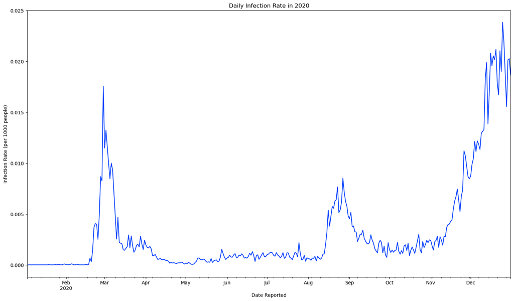

```python
# Filtering data for the year 2020. As this should correspond other datasets
who_data['Date_reported'] = pd.to_datetime(who_data['Date_reported'])
who_data_2020 = who_data[who_data['Date_reported'].dt.year == 2020]

# Merging datasets to get population data
merged_data = who_data_2020.merge(population, on='Country')

# Calculating daily infection rate per 1000 people
merged_data['Infection_rate'] = (merged_data['New_cases'] / merged_data['total population']) * 1000

daily_infection_rate = merged_data.groupby('Date_reported')['Infection_rate'].mean()
plt.figure(figsize=(18, 10))
daily_infection_rate.plot(kind='line')
plt.title('Daily Infection Rate in 2020')
plt.xlabel('Date Reported')
plt.ylabel('Infection Rate (per 1000 people)')
plt.show()
```

Seems that first noticeable Covid infection rate spike is in March 2020. Let's zoom into this.

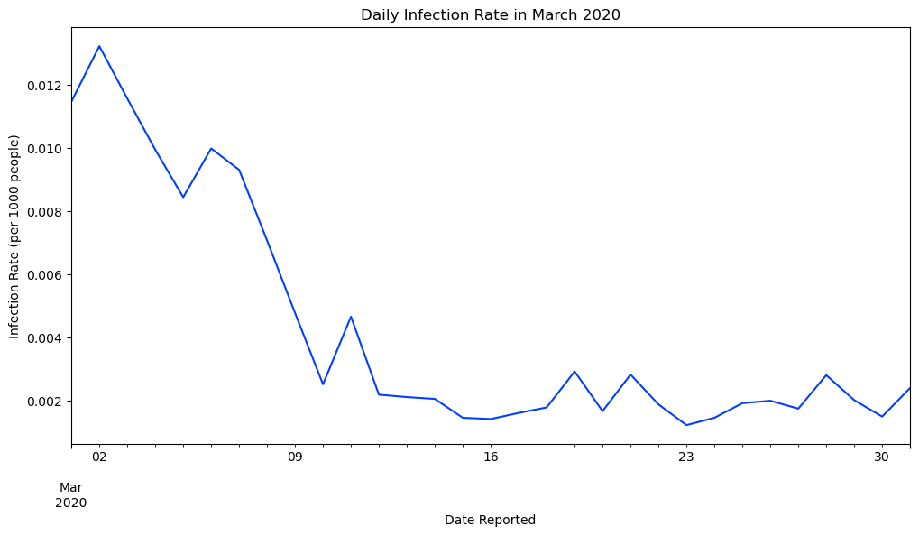

```python
# Filtering data for the year 2020 to align with other datasets
who_data['Date_reported'] = pd.to_datetime(who_data['Date_reported'])
who_data_2022 = who_data[who_data['Date_reported'].dt.year == 2020]

# Filtering data for the month of March 2020
who_data_march_2020 = who_data_2020[(who_data_2020['Date_reported'].dt.month == 3)]

# Merging datasets to get population data
merged_data = who_data_march_2020.merge(population, on='Country')

# Calculating daily infection rate per 1000 people
merged_data['Infection_rate'] = (merged_data['New_cases'] / merged_data['total population']) * 1000

# Grouping data by date and ploting the daily infection rate
daily_infection_rate = merged_data.groupby('Date_reported')['Infection_rate'].mean()
plt.figure(figsize=(12, 6))
daily_infection_rate.plot(kind='line')
plt.title('Daily Infection Rate in March 2020')
plt.xlabel('Date Reported')
plt.ylabel('Infection Rate (per 1000 people)')
plt.show()
```

### Let's make an attempt to predict the daily infection rate for 2022.

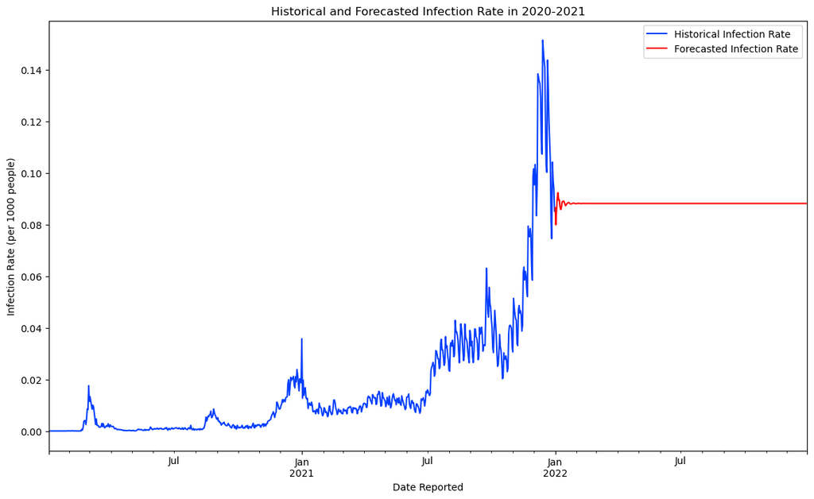

```python
# Filtering data for the years 2020 and 2021
who_data['Date_reported'] = pd.to_datetime(who_data['Date_reported'])
who_data_2020_2021 = who_data[(who_data['Date_reported'].dt.year == 2020) | (who_data['Date_reported'].dt.year == 2021)]

# Merging datasets to get population data
merged_data = who_data_2020_2021.merge(population, on='Country')

# Calculating daily infection rate per 1000 people
merged_data['Infection_rate'] = (merged_data['New_cases'] / merged_data['total population']) * 1000

# Creating a time series
time_series = pd.Series(merged_data['Infection_rate'].values, index=merged_data['Date_reported'])

# Fiting ARIMA model
model = ARIMA(time_series, order=(5, 1, 0))  # Example order; adjust as needed
model_fit = model.fit()

# Forecasting for the upcoming year (365 days)
forecast = model_fit.forecast(steps=365)

# Creating a date range for the forecasted period
forecast_dates = pd.date_range(start=merged_data['Date_reported'].max(), periods=365, freq='D')

# Ploting the historical and forecasted data
plt.figure(figsize=(14, 8))
time_series.plot(label='Historical Infection Rate')
forecast_series = pd.Series(forecast, index=forecast_dates)
forecast_series.plot(label='Forecasted Infection Rate', color='red')
plt.title('Historical and Forecasted Infection Rate in 2020-2021')
plt.xlabel('Date Reported')
plt.ylabel('Infection Rate (per 1000 people)')
plt.legend()
plt.show()
```

#### Average Forecasted Infection Rate per 1000 people for 2022 - 0.088

#### Actual Average Infection Rate per 1000 people for 2022 was 1.502

**Suggestion:**  
Effective communication strategies are crucial during outbreaks. The public needs to be informed of the situation, preventive measures, and vaccination campaigns. Public health campaigns should be designed to address various age groups.

### Let's check how confirmed cases look over time by province.

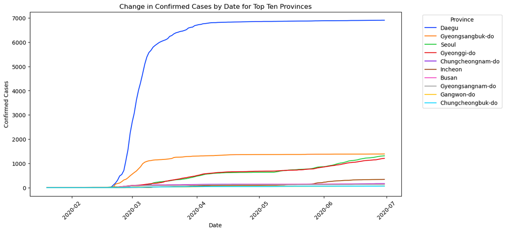

```python
time_province['date'] = pd.to_datetime(time_province['date'])

confirmed_by_date_province = time_province.groupby(['date', 'province'])['confirmed'].sum().reset_index()

pivot_table = confirmed_by_date_province.pivot(index='date', columns='province', values='confirmed')

top_provinces = pivot_table.sum().sort_values(ascending=False).head(10).index

pivot_table_top = pivot_table[top_provinces]

plt.figure(figsize=(12, 6))
sns.lineplot(data=pivot_table_top, dashes=False)
plt.xlabel('Date')
plt.ylabel('Confirmed Cases')
plt.title('Change in Confirmed Cases by Date for Top Ten Provinces')
plt.xticks(rotation=45)
plt.legend(title='Province', bbox_to_anchor=(1.05, 1), loc='upper left')
plt.show()
```

Daegu province leading in confirmed cases, also one of first province that started to report an increased number of confirmed cases.